# Machine Learning Project

Martin Halwachs

25 Mai 2017

# requirements

- predict the `classe` variable
- create report
- describe how you **build the model**
- describe how you use **cross validation**
- estimate the **out of sample error**
- explain why you made your choices
- github repository
  - R markdown file
  - compiled HTM file
  - less than 2000 words
  - less than 5 figures
  - submit with a gh-pages branch = allow online view of HTML

for the quiz you will need to:

- predict 20 different test cases with your model

# introduction

For this course project data will be used from http://groupware.les.inf.puc-rio.br/har. 6 participants were asked to perform barbell lifts correctly and incorrectly in 5 different ways. There activity was tracked by accelerometers on the belt, forearm, arm and dumbell. We will try to find a model, allowing to qualify a participant’s quality of activity in terms of correctness.

# libraries

This project needs the following libraries. In case you don’t have them installed, you may use `install.packages()` function

```r
library(dplyr)
```

# Preparing the data set

First training and test data is loaded from the web and into `trainData` and `quizData`

```r
if(!file.exists("training.csv"))
{
  trainURL <- "http://d396qusza40orc.cloudfront.net/predmachlearn/pml-training.csv"
  download.file(trainURL, destfile="training.csv", method="curl")
}
if(!file.exists("quiz.csv"))
{
  quizURL <- "http://d396qusza40orc.cloudfront.net/predmachlearn/pml-testing.csv"
  download.file(quizURL, destfile="quiz.csv", method="curl")
}

trainData <- read.table("training.csv", header=TRUE, sep=",", na.strings = "NA",
                        stringsAsFactors=FALSE)
quizData <- read.table("quiz.csv", header=TRUE, sep=",", na.strings = "NA",
                        stringsAsFactors=FALSE)
```

These data sets contain the following amount of data

```r
dim(trainData)
```

```
## [1] 19622   160
```

```r
dim(quizData)
```

```
## [1]  20 160
```

## filtering variables

These columns are in the training, but not in the testing set

```r
train.but.not.in.quiz <- names(trainData)[!names(trainData) %in% names(quizData)]
train.but.not.in.quiz
```

```
## [1] "classe"
```

Therefore all data, but ‘classe’ are contained in the quiz set, while quiz contains the column `problem_id` (as column number of the data sets is equal). From all columns the ones with NAs in `quizData` can be excluded from model building, as they allow no prediction:

```r
nas.in.quizData <- apply(is.na(quizData), 2, sum)
nas.in.quizData <- nas.in.quizData[nas.in.quizData>0]
```

As the minimum number of NAs per variable is 20 and the testing set only contains 20 rows, these can all be excluded from training and quiz data set.

```r
trainData <- trainData[,! names(trainData) %in% names(nas.in.quizData)]
quizData <- quizData[,! names(quizData) %in% names(nas.in.quizData)]
```

This leaves 19622, 60 variables in `trainData` and `quizData` (including the predict)

Next `classe` and `user_name` are formatted to factors

```r
trainData$classe <- as.factor(trainData$classe)
trainData$user_name <- as.factor(trainData$user_name)
quizData$user_name <- as.factor(quizData$user_name)
```

## correcting the timestamp

the data contains two timestamps: `raw_timestamp_part_1` and `raw_timestamp_part_2`, besides the human readable `cvtd_timestamp`. Comparing `part_1` with the `cvtd`, we find, that it contains the main time

```r
as.POSIXct(head(trainData$raw_timestamp_part_1),origin="1970-01-01",tz="GMT")
```

```
## [1] "2011-12-05 11:23:51 GMT" "2011-12-05 11:23:51 GMT"
## [3] "2011-12-05 11:23:51 GMT" "2011-12-05 11:23:52 GMT"
## [5] "2011-12-05 11:23:52 GMT" "2011-12-05 11:23:52 GMT"
```

```r
head(trainData$cvtd_timestamp)
```

```
## [1] "05/12/2011 11:23" "05/12/2011 11:23" "05/12/2011 11:23"
## [4] "05/12/2011 11:23" "05/12/2011 11:23" "05/12/2011 11:23"
```

So what about `part_2`? This seems to be the milliseconds. Because, if we look at the first 44 elements, or at a plot versus data line number, we find a periodicity in a growth from 0 to 1,000,000 with following step to 0 again.

```r
head(trainData$raw_timestamp_part_2,n=44)
```

```
##  [1] 788290 808298 820366 120339 196328 304277 368296 440390 484323 484434
## [11] 500302 528316 560359 576390 604281 644302 692324 732306 740353 788335
## [21] 876301 892313 932285 996313  28311  56286  72305 120363 136333 144318
## [31] 152353 244310 304292 332328 340386 412295 448310 468406 504293 512347
## [41] 512367 572298 572351 604309
```

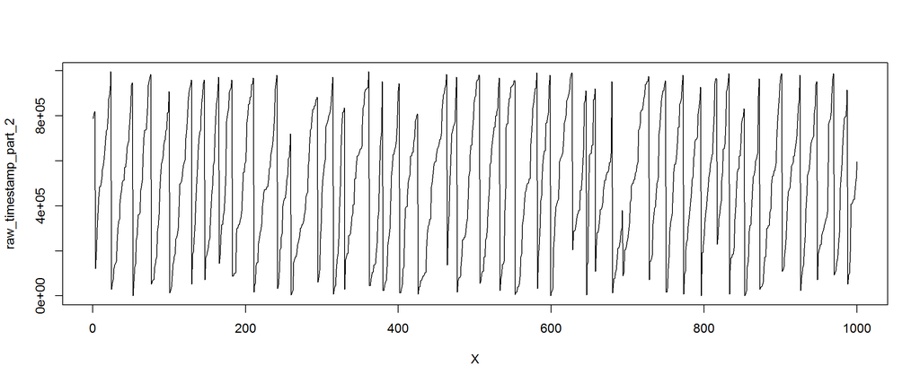

```r
with(head(trainData,n=1000), plot(x=X, y=raw_timestamp_part_2,type="l"))
```

Therefore these 3 variables may be put into 1 timestamp column, this is demonstrated with `temp1` and `temp2` first.

```r
total.time <- function(part1, part2)
{
  as.POSIXct(part1,origin="1970-01-01",tz="GMT")+part2/1E6
}
temp1 <- as.POSIXct(head(trainData$raw_timestamp_part_1),origin="1970-01-01",tz="GMT")
temp2 <- total.time(head(trainData$raw_timestamp_part_1),head(trainData$raw_timestamp_part_2))
data.frame(just.part1=format(temp1, "%Y-%m-%d %H:%M:%OS6"),
           millis=head(trainData$raw_timestamp_part_2),
           total.time=format(temp2, "%Y-%m-%d %H:%M:%OS6"))
```

```
##                   just.part1 millis                 total.time
## 1 2011-12-05 11:23:51.000000 788290 2011-12-05 11:23:51.788290
## 2 2011-12-05 11:23:51.000000 808298 2011-12-05 11:23:51.808298
## 3 2011-12-05 11:23:51.000000 820366 2011-12-05 11:23:51.820365
## 4 2011-12-05 11:23:52.000000 120339 2011-12-05 11:23:52.120338
## 5 2011-12-05 11:23:52.000000 196328 2011-12-05 11:23:52.196327
## 6 2011-12-05 11:23:52.000000 304277 2011-12-05 11:23:52.304276
```

Neglecting minor rounding errors on the last digits, this is applied to training and quiz data set, deleting the other time columns. Further we dismiss the line number `X`

```r
trainData$timestamp <- total.time(trainData$raw_timestamp_part_1, trainData$raw_timestamp_part_2)
quizData$timestamp <- total.time(quizData$raw_timestamp_part_1, quizData$raw_timestamp_part_2)
trainData <- select(trainData, -c(raw_timestamp_part_1, raw_timestamp_part_2, cvtd_timestamp, X))
quizData <- select(quizData, -c(raw_timestamp_part_1, raw_timestamp_part_2, cvtd_timestamp, X))
```

## the tidy data set

Now the training data set has the following variables

```r
names(trainData)
```

```
##  [1] "user_name"            "new_window"           "num_window"
##  [4] "roll_belt"            "pitch_belt"           "yaw_belt"
##  [7] "total_accel_belt"     "gyros_belt_x"         "gyros_belt_y"
## [10] "gyros_belt_z"         "accel_belt_x"         "accel_belt_y"
## [13] "accel_belt_z"         "magnet_belt_x"        "magnet_belt_y"
## [16] "magnet_belt_z"        "roll_arm"             "pitch_arm"
## [19] "yaw_arm"              "total_accel_arm"      "gyros_arm_x"
## [22] "gyros_arm_y"          "gyros_arm_z"          "accel_arm_x"
## [25] "accel_arm_y"          "accel_arm_z"          "magnet_arm_x"
## [28] "magnet_arm_y"         "magnet_arm_z"         "roll_dumbbell"
## [31] "pitch_dumbbell"       "yaw_dumbbell"         "total_accel_dumbbell"
## [34] "gyros_dumbbell_x"     "gyros_dumbbell_y"     "gyros_dumbbell_z"
## [37] "accel_dumbbell_x"     "accel_dumbbell_y"     "accel_dumbbell_z"
## [40] "magnet_dumbbell_x"    "magnet_dumbbell_y"    "magnet_dumbbell_z"
## [43] "roll_forearm"         "pitch_forearm"        "yaw_forearm"
## [46] "total_accel_forearm"  "gyros_forearm_x"      "gyros_forearm_y"
## [49] "gyros_forearm_z"      "accel_forearm_x"      "accel_forearm_y"
## [52] "accel_forearm_z"      "magnet_forearm_x"     "magnet_forearm_y"
## [55] "magnet_forearm_z"     "classe"               "timestamp"
```

# model building

For model building we split `trainData` in a set for `training` and a set for `testing`

```r
library(caret)
set.seed(1)
inTrain <- createDataPartition(y=trainData$classe, p=0.75, list=FALSE)
training <- trainData[inTrain,]
testing <- trainData[-inTrain,]
```

Now a model will be developed on the the training set

```r
dim(training)
```

```
## [1] 14718    57
```

## find important variables

First we try to find out about the importance of the time stamp for prediction:

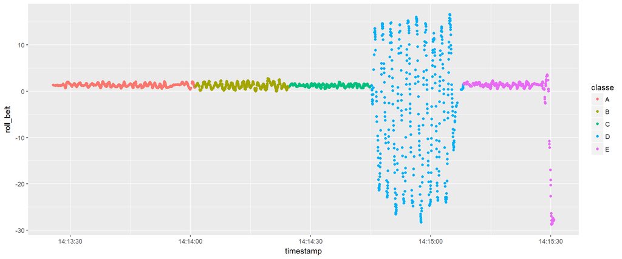

```r
library(ggplot2)
p <- ggplot(filter(training, timestamp < "2011-11-30"), aes(x=timestamp, y=roll_belt, colour=classe))
p + geom_point()
```

From this plot, it is clear, the the instructions were confusing, and we don’t need to predict whether a certaing activity was performed wrong or right. We need to predict, the activity performed. Therefore we can neglect the variables `timestamp`, `new_window` and `num_window` as they have a predefined correlation with `classe`, not allowing general prediction. Same goes for `user_name`

```r
training <- select(training, -c(timestamp, new_window, num_window, user_name))
```

Let’s try to find highly correlated data with a simple method. A correlation matrix is calculated from all remaining columns, but `classe` and `user_name`. this can further be analyzed with the `findCorrelation` function

```r
corrMatrix <- cor(select(training,-c(classe)))
corrCols.names <- findCorrelation(corrMatrix, names=TRUE, cutoff=0.90)
corrCols <- as.numeric(lapply(corrCols.names, FUN=grep, x=names(training)))
corrCols.names
```

```
## [1] "accel_belt_z"     "roll_belt"        "accel_belt_y"
## [4] "accel_belt_x"     "gyros_dumbbell_x" "gyros_dumbbell_z"
## [7] "gyros_arm_x"
```

```r
corrCols
```

```
## [1] 10  1  9  8 31 33 18
```

These columns show a high correlation with some other column and are therefore removed

```r
dim(training)
```

```
## [1] 14718    53
```

```r
training <- training[,-corrCols]
dim(training)
```

```
## [1] 14718    46
```

All remaining variables are then plotted against `classe` to reveal if logarithm of any variable is needed. Further this plot allows to compare all variables for their correlation with the desired predictor.

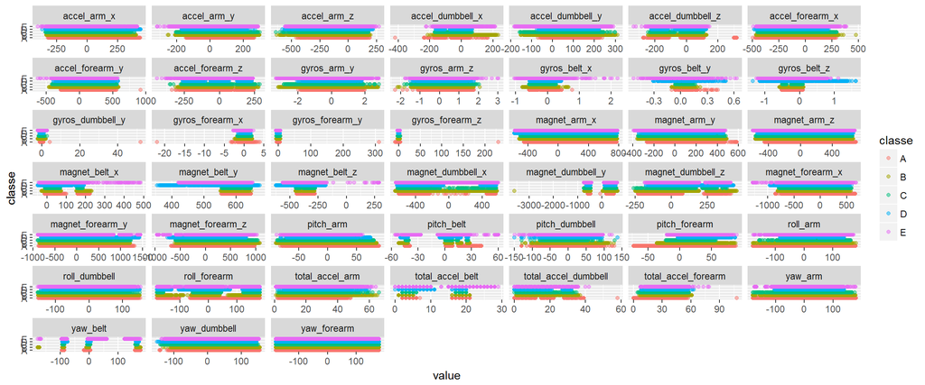

```r
library(tidyr)
plotData <- gather(training, variable, value, -classe)
p <- ggplot(plotData, aes(x=value, y=classe, colour=classe))
p + geom_point(alpha=0.5) + facet_wrap(~variable, scale="free_x")
```

This contains several plots, where outliers do not reveal the variability of each variable. In the replot, the outliers are omitted.

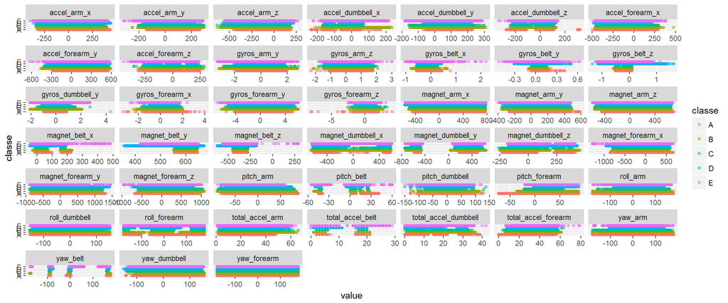

```r
plotData <- filter(training, gyros_dumbbell_y<20 &
                             gyros_forearm_x>-15 &
                             gyros_forearm_y<100 &
                             gyros_forearm_z<100 &
                             magnet_dumbbell_y>-2000)
plotData <- gather(plotData, variable, value, -classe)
p <- ggplot(plotData, aes(x=value, y=classe, colour=classe))
p + geom_point(alpha=0.5) + facet_wrap(~variable, scale="free_x")
```

All data show good variability. An additional logarithm is not needed.

## the model

First we try a simple model with all remaining variables using **regression trees**

```r
modFit.simple <- train(classe ~ ., data=training, method="rpart")
```

The validation on the training set looks like this, with the according accuracy

```r
predClasse <- predict(modFit.simple,training[,-grep("classe",names(training))])
table(predClasse, training$classe)
```

```
##
## predClasse    A    B    C    D    E
##          A 3810 1155 1181  927  606
##          B   67  892   84   31  377
##          C  305  713 1300  835  713
##          D    0   84    1  409  132
##          E    3    4    1  210  878
```

```r
accuracy <- sum(predClasse == training$classe)/length(predClasse)
accuracy
```

```
## [1] 0.4952439
```

This is too inaccurate. Therefore we try to reduce the variables to the ones above showing in-equal distributions

```r
training.sub <- select(training, c(gyros_arm_y, gyros_belt_x, gyros_belt_y, gyros_belt_z,
                               gyros_dumbbell_y, gyros_forearm_x, gyros_forearm_z,
                               magnet_belt_x, magnet_belt_y, magnet_belt_z,
                               magnet_dumbbell_x, magnet_dumbbell_y, pitch_belt,
                               pitch_forearm, roll_arm, roll_forearm, total_accel_belt,
                               yaw_arm, yaw_belt, classe))
```

Then we train a model with these

```r
modFit.reduced <- train(classe ~ ., data=training.sub, method="rpart")
```

This results in the following accuracy

```r
predClasse <- predict(modFit.reduced,training.sub[,-grep("classe",names(training.sub))])
table(predClasse, training.sub$classe)
```

```
##
## predClasse    A    B    C    D    E
##          A 3810 1155 1181  927  606
##          B   67  976   85  440  509
##          C  217  329 1104  333  360
##          D   88  384  196  502  353
##          E    3    4    1  210  878
```

```r
accuracy <- sum(predClasse == training$classe)/length(predClasse)
accuracy
```

```
## [1] 0.493953
```

But this is still too inaccurate and even worse than above. In this case of various varibles, which seem to have different correlation to the predictor, **adaboost** may be helpful, which is implemented in the `gbm` method. Let’s try it on both the training data set and the reduced data set.

```r
modFit.ada <- train(classe ~ ., data=training, method="gbm", verbose=FALSE)
```

Application to the training set shows

```r
predClasse <- predict(modFit.ada,training[,-grep("classe",names(training))])
table(predClasse, training$classe)
```

```
##
## predClasse    A    B    C    D    E
##          A 4138   59    0    2    2
##          B   35 2720   65    7   24
##          C    6   62 2472   65   25
##          D    5    1   26 2330   26
##          E    1    6    4    8 2629
```

```r
accuracy <- sum(predClasse == training$classe)/length(predClasse)
accuracy
```

```
## [1] 0.970852
```

And on the reduced data set…

```r
modFit.ada.reduced <- train(classe ~ ., data=training.sub, method="gbm", verbose=FALSE)
```

Which results in the following accuracy

```r
predClasse <- predict(modFit.ada.reduced,training.sub[,-grep("classe",names(training.sub))])
table(predClasse, training.sub$classe)
```

```
##
## predClasse    A    B    C    D    E
##          A 4091   94    0   13    0
##          B   56 2634   81    7   28
##          C   13   95 2440   55   68
##          D   15   12   33 2302   31
##          E   10   13   13   35 2579
```

```r
accuracy <- sum(predClasse == training$classe)/length(predClasse)
accuracy
```

```
## [1] 0.9543416
```

A more sophisticated approach would be using **random forest method**. This already includes the **cross validation**. After loading the appropriate library

```r
library(randomForest)
```

The method is applied

```r
modFit <- train(classe ~ ., data=training, method="rf")
```

Examine the accuracy of this model with the training set

```r
predClasse <- predict(modFit,training[,-grep("classe",names(training))])
table(predClasse, training$classe)
```

```
##
## predClasse    A    B    C    D    E
##          A 4185    0    0    0    0
##          B    0 2848    0    0    0
##          C    0    0 2567    0    0
##          D    0    0    0 2412    0
##          E    0    0    0    0 2706
```

```r
accuracy <- sum(predClasse == training$classe)/length(predClasse)
accuracy
```

```
## [1] 1
```

```r
predClasse <- predict(modFit, testing)
table(predClasse, testing$classe)
```

```
##
## predClasse    A    B    C    D    E
##          A 1392    4    0    0    0
##          B    2  943    3    0    0
##          C    1    2  850    6    1
##          D    0    0    2  797    3
##          E    0    0    0    1  897
```

```r
accuracy <- sum(predClasse == testing$classe)/length(predClasse)
accuracy
```

```
## [1] 0.9949021
```

The **out of sample error** is the remainder from accuracy to 100%

```r
out.of.sample.error <- 1 - sum(predClasse == testing$classe)/length(predClasse)
out.of.sample.error
```

```
## [1] 0.005097879
```

So about 0.51% of error, with an accuracy of 99.49%.